# 20201110-p8119_hw3_jsg2145

Jared Garfinkel

11/10/2020

```r
tibble(Chapter = c(7, 10, 11),
       Problems = c("9", "2, 3", "3"))
```

```
## # A tibble: 3 x 2
##   Chapter Problems
##     <dbl> <chr>
## 1       7 9
## 2      10 2, 3
## 3      11 3
```

# Chapter 7

## Problem 9

```r
data = read_delim("./data/Takei_SNPs.txt", delim = " ")
data
```

```
## # A tibble: 35 x 8
##    SNPID       MAF    MM    Mm    mm  MM_1  Mm_1  mm_1
##    <chr>     <dbl> <dbl> <dbl> <dbl> <dbl> <dbl> <dbl>
##  1 rs419010  0.493   112   278   150   206   348   150
##  2 rs394221  0.487   149   269    91   153   325   180
##  3 rs4803766 0.434   136   273   130   265   328   107
##  4 rs395908  0.28    228   240    70   414   261    26
##  5 rs519113  0.273   237   226    73   423   258    23
##  6 rs412776  0.257   245   230    65   440   237    19
##  7 rs3865427 0.209   299   198    43   481   206    14
##  8 rs3852860 0.321   191   268    77   359   292    36
##  9 rs3852861 0.318   196   261    80   375   294    39
## 10 rs6857    0.18    316   184    26   504   183    11
## # ... with 25 more rows
```

To test $H_0$: $p_{cases}$ = $p_{controls}$ without assuming HWE,

```r
summary_table = data %>%
  group_by(SNPID) %>%
  summarize(r_M = 2*MM+Mm,
            r_m = 2*mm+Mm,
            s_M = 2*MM_1 + Mm_1,
            s_m = 2*mm_1 + Mm_1,
            n_M = 2*(MM + MM_1) + (Mm + Mm_1),
            n_m = 2*(mm + mm_1) + (Mm + Mm_1),
            r = MM + Mm + mm,
            s = MM_1 + Mm_1 + mm_1,
            n = MM + Mm + mm + MM_1 + Mm_1 + mm_1,
            xcases = (2*MM + Mm)/r,
            xcontrols = (2*MM_1 + Mm_1)/s,
            pcases = xcases/2,
            pcontrols = xcontrols/2,
            x = (xcases + xcontrols)/2,
            p = (pcases + pcontrols)/2,
            zt = 2*sqrt(r*s)*(pcases - pcontrols)/sqrt(4*(MM+MM_1)+(Mm+Mm_1)-4*n*p^2))

summary_table
```

```
## # A tibble: 35 x 17
##    SNPID   r_M   r_m   s_M   s_m   n_M   n_m     r     s     n xcases xcontrols
##    <chr> <dbl> <dbl> <dbl> <dbl> <dbl> <dbl> <dbl> <dbl> <dbl>  <dbl>     <dbl>
##  1 rs10~   723   357  1207   215  1930   572   540   711  1251   1.34     1.70
##  2 rs11~  1052    30  1314    88  2366   118   541   701  1242   1.94     1.87
##  3 rs11~   838   248   992   414  1830   662   543   703  1246   1.54     1.41
##  4 rs15~   646   432   675   725  1321  1157   539   700  1239   1.20     0.964
##  5 rs15~   639   431  1007   375  1646   806   535   691  1226   1.19     1.46
##  6 rs15~   664   400  1084   322  1748   722   532   703  1235   1.25     1.54
##  7 rs15~   987    71  1352    34  2339   105   529   693  1222   1.87     1.95
##  8 rs15~   992    70  1372    36  2364   106   531   704  1235   1.87     1.95
##  9 rs28~   997    75  1381    35  2378   110   536   708  1244   1.86     1.95
## 10 rs38~   650   422  1010   364  1660   786   536   687  1223   1.21     1.47
## # ... with 25 more rows, and 5 more variables: pcases <dbl>, pcontrols <dbl>,
## #   x <dbl>, p <dbl>, zt <dbl>
```

```r
# zt = 2*sqrt(pcases -pcontrol)
```

```r
OR_tab = data %>%
  summarize(MM = sum(MM),
            Mm = sum(Mm),
            mm = sum(mm),
            MM_1 = sum(MM_1),
            Mm_1 = sum(Mm_1),
            mm_1 = sum(mm_1))
tibble(Status =
         c("Cases", "Controls"),
       `Exposed (r1)` =
         c(Disease = pull(OR_tab, Mm),
                Control = pull(OR_tab, Mm_1)),
       `Unexposed (r0)` =
         c(Disease = pull(OR_tab, MM),
                Control = pull(OR_tab, MM_1)))
```

```
## # A tibble: 2 x 3
##   Status   `Exposed (r1)` `Unexposed (r0)`
##   <chr>             <dbl>            <dbl>
## 1 Cases              6300            10581
## 2 Controls           6983            16053
```

```r
  # unnest(cols = c(Exposed, Unexposed))
```

$OR_{r_1}$ = a * d / b * c = 1.369

```r
tibble(Status =
         c("Cases", "Controls"),
       `Exposed (r2)` =
         c(Disease = pull(OR_tab, mm),
                Control = pull(OR_tab, mm_1)),
       `Unexposed (r0)` =
         c(Disease = pull(OR_tab, MM),
                Control = pull(OR_tab, MM_1)))
```

```
## # A tibble: 2 x 3
##   Status   `Exposed (r2)` `Unexposed (r0)`
##   <chr>             <dbl>            <dbl>
## 1 Cases              1876            10581
## 2 Controls           1451            16053
```

$OR_{r_2}$ = 1.962

# Chapter 10

## Problem 2

Compute the Bonferroni correction for the SNPs.

There are 35 SNPs.

So, we divide the significance level by 35.

$\alpha \le M*\alpha'$ = 0.00143

$Z_T \le \phi(0.00143)$

```r
# qnorm(1-0.00143)
summary_table %>%
  mutate(zt2 = zt^2,
         chisq = qchisq(1-0.00143, 1)) %>%
  filter(abs(zt2)>chisq)
```

```
## # A tibble: 35 x 19
##    SNPID   r_M   r_m   s_M   s_m   n_M   n_m     r     s     n xcases xcontrols
##    <chr> <dbl> <dbl> <dbl> <dbl> <dbl> <dbl> <dbl> <dbl> <dbl>  <dbl>     <dbl>
##  1 rs10~   723   357  1207   215  1930   572   540   711  1251   1.34     1.70
##  2 rs11~  1052    30  1314    88  2366   118   541   701  1242   1.94     1.87
##  3 rs11~   838   248   992   414  1830   662   543   703  1246   1.54     1.41
##  4 rs15~   646   432   675   725  1321  1157   539   700  1239   1.20     0.964
##  5 rs15~   639   431  1007   375  1646   806   535   691  1226   1.19     1.46
##  6 rs15~   664   400  1084   322  1748   722   532   703  1235   1.25     1.54
##  7 rs15~   987    71  1352    34  2339   105   529   693  1222   1.87     1.95
##  8 rs15~   992    70  1372    36  2364   106   531   704  1235   1.87     1.95
##  9 rs28~   997    75  1381    35  2378   110   536   708  1244   1.86     1.95
## 10 rs38~   650   422  1010   364  1660   786   536   687  1223   1.21     1.47
## # ... with 25 more rows, and 7 more variables: pcases <dbl>, pcontrols <dbl>,
## #   x <dbl>, p <dbl>, zt <dbl>, zt2 <dbl>, chisq <dbl>
```

It appears that all the SNPs are significant even using the Bonferroni adjustment.

## Problem 3

```r
summary_table %>%
  mutate(p_zt = dnorm(zt)) %>%
  arrange(p_zt) %>%
  mutate(rank_p_zt = row_number(),
         FDR = rank_p_zt/35*0.05) %>%
  filter(p_zt < FDR)
```

```
## # A tibble: 35 x 20
##    SNPID   r_M   r_m   s_M   s_m   n_M   n_m     r     s     n xcases xcontrols
##    <chr> <dbl> <dbl> <dbl> <dbl> <dbl> <dbl> <dbl> <dbl> <dbl>  <dbl>     <dbl>
##  1 rs42~   798   296  1304   126  2102   422   547   715  1262  1.46       1.82
##  2 rs44~   793   281  1265   137  2058   418   537   701  1238  1.48       1.80
##  3 rs10~   723   357  1207   215  1930   572   540   711  1251  1.34       1.70
##  4 rs72~   860   218  1317   101  2177   319   539   709  1248  1.60       1.86
##  5 rs48~   761   315  1180   196  1941   511   538   688  1226  1.41       1.72
##  6 rs15~   664   400  1084   322  1748   722   532   703  1235  1.25       1.54
##  7 rs41~   720   360  1117   275  1837   635   540   696  1236  1.33       1.60
##  8 rs51~   700   372  1104   304  1804   676   536   704  1240  1.31       1.57
##  9 rs39~   696   380  1089   313  1785   693   538   701  1239  1.29       1.55
## 10 rs44~   520   528   841   481  1361  1009   524   661  1185  0.992      1.27
## # ... with 25 more rows, and 8 more variables: pcases <dbl>, pcontrols <dbl>,
## #   x <dbl>, p <dbl>, zt <dbl>, p_zt <dbl>, rank_p_zt <int>, FDR <dbl>
```

All the p-values are significant using a modified Simes-procedure.

For all (i), $p_i < \frac{(i)}{M}\alpha$

# Chapter 11

## Problem 3

$1 - \alpha$ = P(for i SNPs, $H_0$ is not rejected when the null is true)

$$1 - \alpha = \sum_{i = 0}^{M}\left[{M \choose i} (\alpha_1(1-\alpha_2))^i(1-\alpha_1)^{m-i}\right]$$

=
$$[\alpha_1(1-\alpha_2) + (1-\alpha_1)]^M$$

Since $(1-\alpha)^\frac{1}{M}$ ~ $1 - \frac{\alpha}{M}$,

$$\frac{\alpha}{M} = \alpha_1*\alpha_2*...*\alpha_K$$

Thus,
$$\frac{\alpha}{M} = \prod_{k = 1}^{M}\alpha_i$$

# SKAT

```r
data(SKAT.example)
names(SKAT.example)
```

```
## [1] "Z"   "X"   "y.c" "y.b"
```

```r
attach(SKAT.example)
```

```r
skimr::skim(SKAT.example)
```

Data summary

| Name | SKAT.example |
| --- | --- |
| Number of rows | 2000 |
| Number of columns | 71 |
| _______________________ |  |
| Column type frequency: |  |
| numeric | 71 |
| ________________________ |  |
| Group variables | None |

**Variable type: numeric**

| skim_variable | n_missing | complete_rate | mean | sd | p0 | p25 | p50 | p75 | p100 | hist |
| --- | --- | --- | --- | --- | --- | --- | --- | --- | --- | --- |
| Z.1 | 0 | 1 | 0.00 | 0.03 | 0.00 | 0.00 | 0.00 | 0.00 | 1.00 | ▇▁▁▁▁ |
| Z.2 | 0 | 1 | 0.00 | 0.02 | 0.00 | 0.00 | 0.00 | 0.00 | 1.00 | ▇▁▁▁▁ |
| Z.3 | 0 | 1 | 0.00 | 0.03 | 0.00 | 0.00 | 0.00 | 0.00 | 1.00 | ▇▁▁▁▁ |
| Z.4 | 0 | 1 | 0.00 | 0.04 | 0.00 | 0.00 | 0.00 | 0.00 | 1.00 | ▇▁▁▁▁ |
| Z.5 | 0 | 1 | 0.29 | 0.49 | 0.00 | 0.00 | 0.00 | 1.00 | 2.00 | ▇▁▃▁▁ |
| Z.6 | 0 | 1 | 0.22 | 0.45 | 0.00 | 0.00 | 0.00 | 0.00 | 2.00 | ▇▁▂▁▁ |
| Z.7 | 0 | 1 | 0.00 | 0.04 | 0.00 | 0.00 | 0.00 | 0.00 | 1.00 | ▇▁▁▁▁ |
| Z.8 | 0 | 1 | 0.00 | 0.04 | 0.00 | 0.00 | 0.00 | 0.00 | 1.00 | ▇▁▁▁▁ |
| Z.9 | 0 | 1 | 0.00 | 0.03 | 0.00 | 0.00 | 0.00 | 0.00 | 1.00 | ▇▁▁▁▁ |
| Z.10 | 0 | 1 | 0.00 | 0.04 | 0.00 | 0.00 | 0.00 | 0.00 | 1.00 | ▇▁▁▁▁ |
| Z.11 | 0 | 1 | 0.00 | 0.03 | 0.00 | 0.00 | 0.00 | 0.00 | 1.00 | ▇▁▁▁▁ |
| Z.12 | 0 | 1 | 0.00 | 0.02 | 0.00 | 0.00 | 0.00 | 0.00 | 1.00 | ▇▁▁▁▁ |
| Z.13 | 0 | 1 | 0.02 | 0.13 | 0.00 | 0.00 | 0.00 | 0.00 | 1.00 | ▇▁▁▁▁ |
| Z.14 | 0 | 1 | 0.33 | 0.53 | 0.00 | 0.00 | 0.00 | 1.00 | 2.00 | ▇▁▃▁▁ |
| Z.15 | 0 | 1 | 0.00 | 0.03 | 0.00 | 0.00 | 0.00 | 0.00 | 1.00 | ▇▁▁▁▁ |
| Z.16 | 0 | 1 | 0.04 | 0.20 | 0.00 | 0.00 | 0.00 | 0.00 | 1.00 | ▇▁▁▁▁ |
| Z.17 | 0 | 1 | 0.00 | 0.02 | 0.00 | 0.00 | 0.00 | 0.00 | 1.00 | ▇▁▁▁▁ |
| Z.18 | 0 | 1 | 0.01 | 0.12 | 0.00 | 0.00 | 0.00 | 0.00 | 2.00 | ▇▁▁▁▁ |
| Z.19 | 0 | 1 | 0.16 | 0.39 | 0.00 | 0.00 | 0.00 | 0.00 | 2.00 | ▇▁▂▁▁ |
| Z.20 | 0 | 1 | 0.23 | 0.46 | 0.00 | 0.00 | 0.00 | 0.00 | 2.00 | ▇▁▂▁▁ |
| Z.21 | 0 | 1 | 0.00 | 0.03 | 0.00 | 0.00 | 0.00 | 0.00 | 1.00 | ▇▁▁▁▁ |
| Z.22 | 0 | 1 | 0.00 | 0.04 | 0.00 | 0.00 | 0.00 | 0.00 | 1.00 | ▇▁▁▁▁ |
| Z.23 | 0 | 1 | 0.04 | 0.20 | 0.00 | 0.00 | 0.00 | 0.00 | 1.00 | ▇▁▁▁▁ |
| Z.24 | 0 | 1 | 0.22 | 0.45 | 0.00 | 0.00 | 0.00 | 0.00 | 2.00 | ▇▁▂▁▁ |
| Z.25 | 0 | 1 | 0.00 | 0.04 | 0.00 | 0.00 | 0.00 | 0.00 | 1.00 | ▇▁▁▁▁ |
| Z.26 | 0 | 1 | 0.00 | 0.05 | 0.00 | 0.00 | 0.00 | 0.00 | 1.00 | ▇▁▁▁▁ |
| Z.27 | 0 | 1 | 0.01 | 0.12 | 0.00 | 0.00 | 0.00 | 0.00 | 1.00 | ▇▁▁▁▁ |
| Z.28 | 0 | 1 | 0.04 | 0.20 | 0.00 | 0.00 | 0.00 | 0.00 | 1.00 | ▇▁▁▁▁ |
| Z.29 | 0 | 1 | 0.00 | 0.02 | 0.00 | 0.00 | 0.00 | 0.00 | 1.00 | ▇▁▁▁▁ |
| Z.30 | 0 | 1 | 0.00 | 0.02 | 0.00 | 0.00 | 0.00 | 0.00 | 1.00 | ▇▁▁▁▁ |
| Z.31 | 0 | 1 | 0.00 | 0.02 | 0.00 | 0.00 | 0.00 | 0.00 | 1.00 | ▇▁▁▁▁ |
| Z.32 | 0 | 1 | 0.01 | 0.09 | 0.00 | 0.00 | 0.00 | 0.00 | 1.00 | ▇▁▁▁▁ |
| Z.33 | 0 | 1 | 0.01 | 0.10 | 0.00 | 0.00 | 0.00 | 0.00 | 1.00 | ▇▁▁▁▁ |
| Z.34 | 0 | 1 | 0.00 | 0.02 | 0.00 | 0.00 | 0.00 | 0.00 | 1.00 | ▇▁▁▁▁ |
| Z.35 | 0 | 1 | 0.33 | 0.53 | 0.00 | 0.00 | 0.00 | 1.00 | 2.00 | ▇▁▃▁▁ |
| Z.36 | 0 | 1 | 0.00 | 0.02 | 0.00 | 0.00 | 0.00 | 0.00 | 1.00 | ▇▁▁▁▁ |
| Z.37 | 0 | 1 | 0.02 | 0.13 | 0.00 | 0.00 | 0.00 | 0.00 | 1.00 | ▇▁▁▁▁ |
| Z.38 | 0 | 1 | 0.00 | 0.04 | 0.00 | 0.00 | 0.00 | 0.00 | 1.00 | ▇▁▁▁▁ |
| Z.39 | 0 | 1 | 0.01 | 0.12 | 0.00 | 0.00 | 0.00 | 0.00 | 1.00 | ▇▁▁▁▁ |
| Z.40 | 0 | 1 | 0.00 | 0.03 | 0.00 | 0.00 | 0.00 | 0.00 | 1.00 | ▇▁▁▁▁ |
| Z.41 | 0 | 1 | 0.46 | 0.59 | 0.00 | 0.00 | 0.00 | 1.00 | 2.00 | ▇▁▅▁▁ |
| Z.42 | 0 | 1 | 0.00 | 0.02 | 0.00 | 0.00 | 0.00 | 0.00 | 1.00 | ▇▁▁▁▁ |
| Z.43 | 0 | 1 | 0.21 | 0.44 | 0.00 | 0.00 | 0.00 | 0.00 | 2.00 | ▇▁▂▁▁ |
| Z.44 | 0 | 1 | 0.00 | 0.03 | 0.00 | 0.00 | 0.00 | 0.00 | 1.00 | ▇▁▁▁▁ |
| Z.45 | 0 | 1 | 0.00 | 0.03 | 0.00 | 0.00 | 0.00 | 0.00 | 1.00 | ▇▁▁▁▁ |
| Z.46 | 0 | 1 | 0.00 | 0.02 | 0.00 | 0.00 | 0.00 | 0.00 | 1.00 | ▇▁▁▁▁ |
| Z.47 | 0 | 1 | 0.00 | 0.02 | 0.00 | 0.00 | 0.00 | 0.00 | 1.00 | ▇▁▁▁▁ |
| Z.48 | 0 | 1 | 0.01 | 0.12 | 0.00 | 0.00 | 0.00 | 0.00 | 1.00 | ▇▁▁▁▁ |
| Z.49 | 0 | 1 | 0.00 | 0.03 | 0.00 | 0.00 | 0.00 | 0.00 | 1.00 | ▇▁▁▁▁ |
| Z.50 | 0 | 1 | 0.00 | 0.02 | 0.00 | 0.00 | 0.00 | 0.00 | 1.00 | ▇▁▁▁▁ |
| Z.51 | 0 | 1 | 0.26 | 0.48 | 0.00 | 0.00 | 0.00 | 0.00 | 2.00 | ▇▁▂▁▁ |
| Z.52 | 0 | 1 | 0.00 | 0.07 | 0.00 | 0.00 | 0.00 | 0.00 | 1.00 | ▇▁▁▁▁ |
| Z.53 | 0 | 1 | 0.26 | 0.48 | 0.00 | 0.00 | 0.00 | 0.00 | 2.00 | ▇▁▂▁▁ |
| Z.54 | 0 | 1 | 0.00 | 0.06 | 0.00 | 0.00 | 0.00 | 0.00 | 1.00 | ▇▁▁▁▁ |
| Z.55 | 0 | 1 | 0.00 | 0.04 | 0.00 | 0.00 | 0.00 | 0.00 | 1.00 | ▇▁▁▁▁ |
| Z.56 | 0 | 1 | 0.00 | 0.03 | 0.00 | 0.00 | 0.00 | 0.00 | 1.00 | ▇▁▁▁▁ |
| Z.57 | 0 | 1 | 0.10 | 0.32 | 0.00 | 0.00 | 0.00 | 0.00 | 2.00 | ▇▁▁▁▁ |
| Z.58 | 0 | 1 | 0.00 | 0.04 | 0.00 | 0.00 | 0.00 | 0.00 | 1.00 | ▇▁▁▁▁ |
| Z.59 | 0 | 1 | 0.00 | 0.02 | 0.00 | 0.00 | 0.00 | 0.00 | 1.00 | ▇▁▁▁▁ |
| Z.60 | 0 | 1 | 0.00 | 0.02 | 0.00 | 0.00 | 0.00 | 0.00 | 1.00 | ▇▁▁▁▁ |
| Z.61 | 0 | 1 | 0.01 | 0.09 | 0.00 | 0.00 | 0.00 | 0.00 | 1.00 | ▇▁▁▁▁ |
| Z.62 | 0 | 1 | 0.00 | 0.02 | 0.00 | 0.00 | 0.00 | 0.00 | 1.00 | ▇▁▁▁▁ |
| Z.63 | 0 | 1 | 0.00 | 0.02 | 0.00 | 0.00 | 0.00 | 0.00 | 1.00 | ▇▁▁▁▁ |
| Z.64 | 0 | 1 | 0.00 | 0.04 | 0.00 | 0.00 | 0.00 | 0.00 | 1.00 | ▇▁▁▁▁ |
| Z.65 | 0 | 1 | 0.00 | 0.02 | 0.00 | 0.00 | 0.00 | 0.00 | 1.00 | ▇▁▁▁▁ |
| Z.66 | 0 | 1 | 0.00 | 0.03 | 0.00 | 0.00 | 0.00 | 0.00 | 1.00 | ▇▁▁▁▁ |
| Z.67 | 0 | 1 | 0.00 | 0.02 | 0.00 | 0.00 | 0.00 | 0.00 | 1.00 | ▇▁▁▁▁ |
| X.1 | 0 | 1 | 0.50 | 0.50 | 0.00 | 0.00 | 0.50 | 1.00 | 1.00 | ▇▁▁▁▇ |
| X.2 | 0 | 1 | 0.02 | 1.01 | -3.23 | -0.66 | 0.01 | 0.69 | 4.33 | ▁▆▇▂▁ |
| y.c | 0 | 1 | 0.26 | 1.13 | -3.30 | -0.53 | 0.26 | 1.04 | 3.94 | ▁▅▇▃▁ |
| y.b | 0 | 1 | 0.50 | 0.50 | 0.00 | 0.00 | 0.50 | 1.00 | 1.00 | ▇▁▁▁▇ |

There are 67 variables of Z variables. Z variables are mostly 0, but range from 0 to 2.

In the variables X.1 and Y.b there are an equal number of observations taking values of 0 and 1.

X.2 and y.c appear to be continuous variables centered around 0 with a a variance near 1.

```r
df = SKAT.example %>%
  data.frame() %>%
  tibble() %>%
  janitor::clean_names()
```

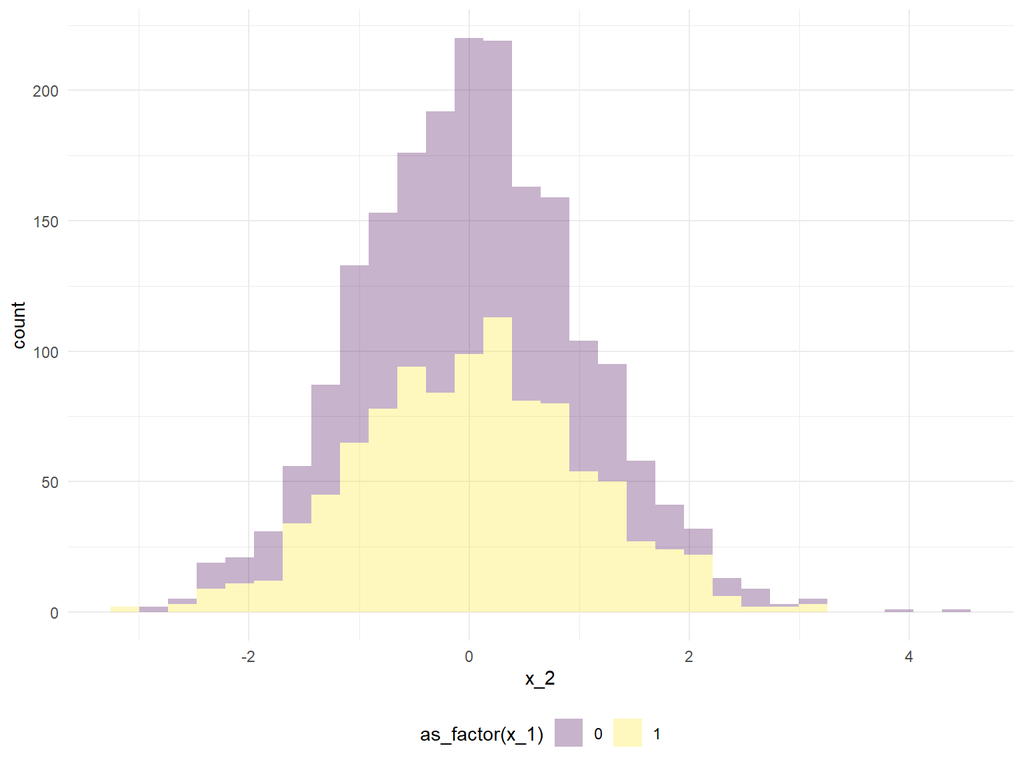

```r
df %>%
  ggplot(aes(x = x_2, fill = as_factor(x_1))) +
  geom_histogram(alpha = 0.3)
```

These variables appear to overlap in most places.

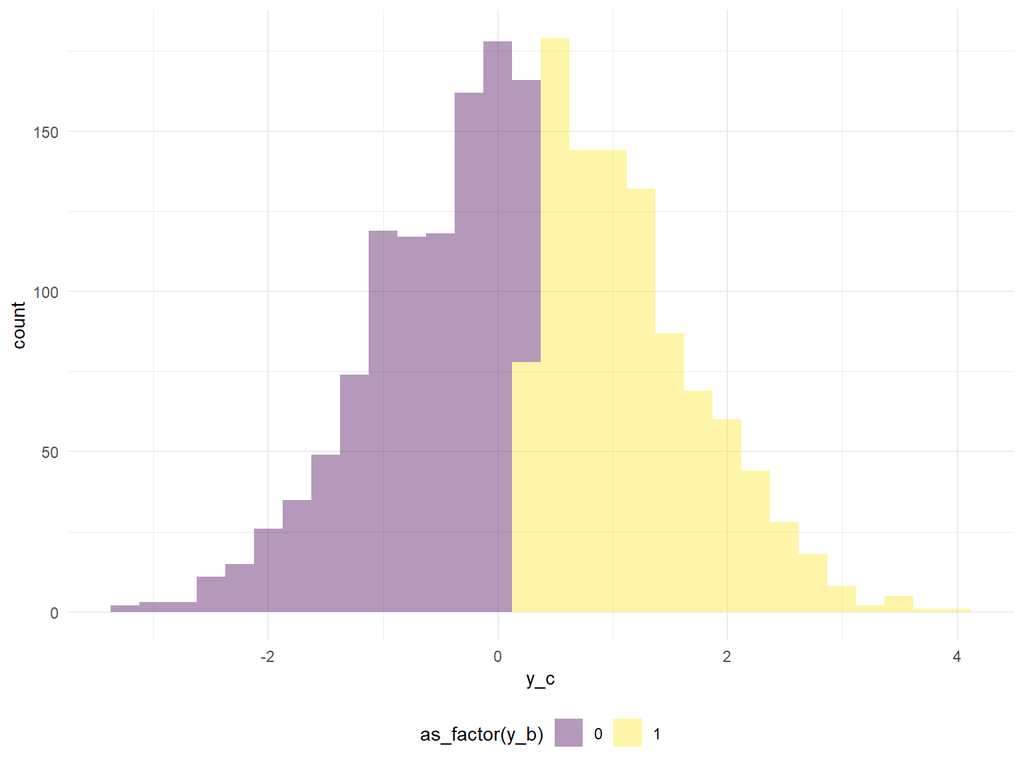

```r
df %>%
  ggplot(aes(x = y_c, fill = as_factor(y_b))) +
  geom_histogram(alpha = 0.4)
```

```r
obj<-SKAT_Null_Model(y.c ~ X, out_type="C", data = SKAT.example)
```

The purpose of the analysis is to find an association between genotypes at one or SNPs among cases and controls.

# Question 2

```r
#SKAT test
SKAT(Z, obj, r.corr=0)$p.value
```

```
## [1] 0.002877041
```

```r
#Burden test
SKAT(Z, obj,r.corr=1)$p.value
```

```
## [1] 0.01507979
```

```r
# SKAT-O: Optimal over r.corr in [0,1]; r.corr is the
# correlation among the beta’s of individual variants in
# the gene.
SKAT(Z, obj, method="optimal")$p.value
```

```
## [1] 0.004022006
```

All of the tests for association show evidence to reject the null hypothesis at an alpha of 0.05. We can therefore reject the null that there is no association between at least one SNP and the disease of interest.

# Question 3

```r
SKAT(Z, obj, r.corr=0,weights.beta=c(0.5,0.5))$p.value
```

```
## [1] 0.02049286
```

```r
SKAT(Z, obj, r.corr=1,weights.beta=c(0.5,0.5))$p.value
```

```
## [1] 0.6063943
```

```r
SKAT(Z,obj,method="optimal.adj",weights.beta=c(0.5,0.5))$p.value
```

```
## [1] 0.04003464
```

When the weighting is implemented, the correlation structure with $\rho$ = 1 finds no evidence to reject the null.

# Question 4

```r
obj<-SKAT_Null_Model(y.c ~ X, out_type="C")

SKAT_CommonRare(Z, obj)$p.value
```

```
## [1] 0.004381306
```

```r
SKAT_CommonRare(Z, obj, r.corr.rare=1, r.corr.common=1, test.type="Joint")$p.value
```

```
## [1] 0.02408793
```

The default joint test of association with common and rare variants uses a correlation of 0. However, when the correlation structure is 1 in the common and rare variants joint test of association, the p-value is higher. This does not affect significance in this case.

# Question 5

```r
data(SKAT.haplotypes)
names(SKAT.haplotypes)
```

```
## [1] "Haplotype" "SNPInfo"
```

```r
attach(SKAT.haplotypes)
```

```r
set.seed(719)
out.c<-Power_Continuous(Haplotype,SNPInfo$CHROM_POS, SubRegion.Length=5000, Causal.Percent= 20, N.Sim=10, MaxBeta=2,Negative.Percent=20)
```

```
## [1] "10/10"
```

```r
out.c
```

```
## $Power
##           0.01     0.001     1e-06
## 500  0.5894658 0.5005445 0.2908597
## 1000 0.7142260 0.6426376 0.5329631
## 1500 0.7946953 0.7105546 0.6084692
## 2000 0.8612765 0.7670665 0.6502879
## 2500 0.9121743 0.8217535 0.6859310
## 3000 0.9473481 0.8690406 0.7119698
## 3500 0.9716506 0.9031020 0.7387509
## 4000 0.9874444 0.9274318 0.7737557
## 4500 0.9957750 0.9477345 0.8133431
## 5000 0.9989890 0.9659572 0.8489484
##
## $R.sq
## [1] 0.07438532
##
## attr(,"class")
## [1] "SKAT_Power"
```

```r
out.c<-Power_Continuous(Haplotype,SNPInfo$CHROM_POS, SubRegion.Length=500,Causal.Percent= 20, N.Sim=10, MaxBeta=2,Negative.Percent=20)
```

```
## [1] "10/10"
```

```r
out.c
```

```
## $Power
##           0.01      0.001      1e-06
## 500  0.1705004 0.09869591 0.01061239
## 1000 0.2548883 0.20023233 0.08183670
## 1500 0.2996887 0.23884612 0.16217885
## 2000 0.3430941 0.26400071 0.20042707
## 2500 0.3871344 0.28900633 0.21668981
## 3000 0.4291432 0.31546414 0.22911336
## 3500 0.4667391 0.34357321 0.24190555
## 4000 0.4989889 0.37277168 0.25472096
## 4500 0.5263707 0.40183855 0.26672699
## 5000 0.5501232 0.42938012 0.27751678
##
## $R.sq
## [1] 0.009369053
##
## attr(,"class")
## [1] "SKAT_Power"
```

A high subregion length results in a higher r-squared and higher power. We therefore choose the larger subregion length.

```r
out.c<-Power_Continuous(Haplotype,SNPInfo$CHROM_POS, SubRegion.Length=5000,Causal.Percent= 10, N.Sim=10, MaxBeta=2,Negative.Percent=20)
```

```
## [1] "10/10"
```

```r
out.c
```

```
## $Power
##           0.01     0.001      1e-06
## 500  0.3042004 0.1811304 0.03219917
## 1000 0.5027933 0.3678246 0.16783736
## 1500 0.6269487 0.4973186 0.28419125
## 2000 0.6896760 0.6004179 0.35808833
## 2500 0.7163989 0.6627503 0.42901666
## 3000 0.7316157 0.6919365 0.50493519
## 3500 0.7460025 0.7043814 0.57321863
## 4000 0.7624545 0.7113255 0.62518661
## 4500 0.7810892 0.7179288 0.66012588
## 5000 0.8010473 0.7260913 0.68113227
##
## $R.sq
## [1] 0.03048279
##
## attr(,"class")
## [1] "SKAT_Power"
```

A lower causal percent results in a lower r-squared and lower power. We therefore choose the larger causal percent.

```r
out.c<-Power_Continuous(Haplotype,SNPInfo$CHROM_POS, SubRegion.Length=5000,Causal.Percent= 20, N.Sim=10, MaxBeta=2,Negative.Percent=20,BetaType = "Fixed")
```

```
## [1] "10/10"
```

```r
out.c
```

```
## $Power
##           0.01     0.001     1e-06
## 500  0.7788163 0.7360389 0.6417681
## 1000 0.8066052 0.7987186 0.7360777
## 1500 0.8146127 0.8017764 0.7931682
## 2000 0.8293619 0.8043023 0.7999308
## 2500 0.8523591 0.8096452 0.8000145
## 3000 0.8818934 0.8196424 0.8000430
## 3500 0.9126445 0.8358817 0.8001224
## 4000 0.9387883 0.8583836 0.8003320
## 4500 0.9581208 0.8846229 0.8008491
## 5000 0.9721324 0.9103342 0.8020266
##
## $R.sq
## [1] 0.155021
##
## attr(,"class")
## [1] "SKAT_Power"
```

```r
out.b<-Power_Logistic(Haplotype,SNPInfo$CHROM_POS, SubRegion.Length=5000,Causal.Percent= 20, N.Sim=10 ,MaxOR=7, Negative.Percent=20)
```

```
## [1] "10/10"
```

```r
out.b
```

```
## $Power
##           0.01     0.001     1e-06
## 500  0.3272449 0.2010873 0.1039439
## 1000 0.5384255 0.4221778 0.1679978
## 1500 0.6133301 0.5469946 0.3138901
## 2000 0.6485489 0.5944153 0.4514738
## 2500 0.6782033 0.6156394 0.5321092
## 3000 0.7102964 0.6310352 0.5729219
## 3500 0.7454704 0.6475533 0.5916826
## 4000 0.7827088 0.6665156 0.5994665
## 4500 0.8204388 0.6876072 0.6033374
## 5000 0.8565694 0.7104226 0.6068298
##
## attr(,"class")
## [1] "SKAT_Power"
```

When the model treats the traits as dichotomous the power is reduced.

```r
Get_RequiredSampleSize(out.c, Power=0.8)
```

```
## $`alpha = 1.00e-02`
## [1] 881.1544
##
## $`alpha = 1.00e-03`
## [1] 1209.535
##
## $`alpha = 1.00e-06`
## [1] 2413.434
```

At varying levels of type I error, the required sample size ranges from 882 to 2414. This will affect the family-wise error rate.